# FINAL PROJECT_YOU

BMIN5030_Fall2023

# 1 Overview

> Sepsis is among the leading causes of hospital readmission, and survivors often experience long-term consequences. Research has shown that home health services can improve the outcomes of sepsis survivors, reducing the likelihood of hospital readmission. This project aims to identify the patient/clinical characteristics that are associated with sepsis survivors’ discharge dispositions (home or home with home health care) and 30-day hospital readmission using Medical Information Mart for Intensive Care (MIMIC-IV) data, which is a publicly accessible and deidentified data.

# 2 Introduction

> Sepsis is a severe condition caused by infection, leading to life-threatening organ dysfunction (Singer et al., 2016). Annually more than 1.7 million adults in the US are diagnosed with sepsis (CDC, 2023), with a majority falling into the age group of 65 or older (Paoli et al., 2018). Despite improvements in healthcare, sepsis survivors in older adults still grapple with elevated mortality rates and lingering physical, psychological, and emotional consequences. A significant proportion of sepsis survivors are readmitted to the hospital within 30 days after initial sepsis hospitalization. Sepsis places a substantial economic burden on society, necessitating post-acute care to address lingering complications. Home health care (HHC) is provided to a significant portion of sepsis survivors to support their recovery and rehabilitation. However, the impact of HHC on reducing 30-day readmission rates for sepsis survivors remains unexplored. This retrospective cohort study, using the MIMIC-IV database, aims to address this gap by examining the following objectives: (1) describe and compare **baseline** patient characteristics (i.e., demographic and clinical characteristics) and 30-day readmission rates of older sepsis survivors discharged home with HHC and without HHC; (2) determine the risk factors associated with 30-day readmission.

> The proposed study involves interdisciplinary collaboration, focusing on the transition of sepsis survivors form acute hospitals to post-acute settings (i.e., home and home health care). Transition is one of the vulnerable points where medical errors occur, as multiple stakeholders and multiple entities are involved in this process. Discharge planning involves a team of professionals, including physicians, nurses, social workers, case managers, and patients and care partners to ensure safe and smooth transition from hospital to home. The findings of the study may offer valuable insights to healthcare providers engaged in discharge planning for older sepsis survivors. By considering the risk factors associated with readmission, this study can serve as a basis for supporting evidence-based recommendations for those who are involved in decision-making for discharge disposition decisions. This, in turn, empowers healthcare decision-makers to strategize discharge planning effectively, with a focus on identifying individuals at one ofthe highest risks of rehospitalization with continuous health concerns.

# 3 Methods

Data were downloaded using Mac Terminal Version 2.11 (440), downloaded in September 2023, via designated terminal <wget -r -N -c -np --user ysb8390 --ask-password https://physionet.org/files/mimiciv/2.2/>. For data analysis, R software (version 4.3.1., CRAN) was used.

## 3.1 Data Source: Overview of MIMIC-IV

MIMIC-IV is a public database, which contains deidentified clinical data of adult patients aged 18 or older admitted to critical care units at the Beth Israel Deaconess Medical Center (BIDMC) in Boston, Massachusetts from either the ED or an ICU (Johnson, 2023). This extensive data contains records from 299,712 patients, encompassing 431,231 hospital admissions and 73,181 ICU stays between 2008 and 2019.

More information about MIMIC can be found here: https://mimic.mit.edu/docs/iv/

Also, there is an online community where conceptualization of variables and codes shared by others using MIMIC: https://github.com/MIT-LCP/mimic-code

## 3.2 Installing/Loading Necessary Packages

```r
install.packages(c("tidyverse", "dplyr", "gtsummary", "ggplot2", "lubridate", "RColorBrewer", "cowplot", "ggpubr", "pROC", "comorbidity", "readr", "janitor", "pacman", "gee", "janitor", "geepack", "modelsummary", "psych", "furniture", "pander", "lme4", "texreg", "MESS"))
```

# 4 Identify Total Number of Hospital Admission

```r
admissions <- read.csv("~/Library/Mobile Documents/com~apple~CloudDocs/Penn/ONR/MIMIC/mimic-iv-2.2/hosp/admissions.csv")

admissions |>
  summarise(n_distinct(hadm_id),
            n_distinct(subject_id))
```

```
  n_distinct(hadm_id) n_distinct(subject_id)
1              431231                 180733
```

```r
admissions <- admissions |>
  mutate(admittime = ymd_hms(admittime),
         dischtime = ymd_hms(dischtime))
```

# 5 Cohort Identification

### 5.0.1 Identifying in-hospital stays (vs. observational stays)

In this study, I will focus on cases when patients had in-hospital stays, meaning hospital length of stays longer than 48 hours to exclude observational stay cases. We will first create a hospital length of stay variable and then filter cases whose hospital length of stay is less than 48 hours (i.e., observational stays).

```r
# Using admissions table

admissions <- admissions |>
  mutate(admittime = ymd_hms(admittime),
         dischtime = ymd_hms(dischtime))
admissions <- admissions |>
  mutate(hosp_los = as.numeric(difftime(dischtime, admittime, units = "days")))

admissions$hosp_los <- round(admissions$hosp_los, digits = 2)

admissions |>
  dplyr::select(hosp_los) |>
  psych::describe()
```

```
         vars      n mean   sd median trimmed  mad   min    max  range skew
hosp_los    1 419712 4.46 6.62   2.72    3.22 2.73 -0.95 295.99 296.94 7.09
         kurtosis   se
hosp_los   111.64 0.01
```

```r
# mean = 4.46 days; min = -0.95; max = 295.99 days

admissions <- admissions |>
  mutate(adm_inhosp = ifelse(hosp_los < 2, 0, 1)) |>
  mutate(adm_inhosp = factor(adm_inhosp, levels = c(0, 1)))

table(admissions$adm_inhosp) # observational stays = 172170; in hospital stays = 247542 (57.4%)
```

```
     0      1
172170 247542
```

```r
hosp_los_inhosp <- admissions |>
  filter(adm_inhosp == 1)

# data frame
# hosp_los_inhosp = in-hospital stays cohort (sourced from admissions table)
# variable
# adm_inhosp = 1 means inhospital stay (hosp_los >= 2days)
```

### 5.0.2 Sepsis Cohort Selection

Sepsis patients will be identified based on international classification of disease (ICD) codes from both the 9th and 10th revisions, as both versions were available in MIMIC. Sepsis cases will be identified through two strategies: (1) explicit ICD-9 codes (995.92, and 785.52) or explicit ICD-10 codes (R65.2, R65.20, and R65.21), and (2) implicit identification method using Angus criteria (Angus, 2001) that considers the case as sepsis when the patient is coded for both infection (i.e., ICD 9 or 10 infection codes) and organ dysfunction (i.e., ICD 9 or 10 organ dysfunction codes). These two strategies are adopted to increase the sensitivity of sepsis diagnosis up to 50% compared to other methods to identify sepsis patients (Iwashyna, 2014; Fleischmann-Struzek, 2018).

Now, I am going to identify how many admissions are associated with sepsis diagnosis using both explicit and implicit methods.

```r
# Diagnosis_icd table
icd  <- read_csv(file="/Users/sangbin/Library/Mobile Documents/com~apple~CloudDocs/Penn/ONR/MIMIC/mimic-iv-2.2/hosp/diagnoses_icd.csv.gz")
# Check data class
str(icd$icd_code) #character
```

```
 chr [1:4756326] "5723" "78959" "5715" "07070" "496" "29680" "30981" ...
```

```r
str(icd$icd_version) #integar
```

```
 num [1:4756326] 9 9 9 9 9 9 9 9 9 9 ...
```

```r
inhosp_icd <- icd |>
  left_join(hosp_los_inhosp, by = c("subject_id", "hadm_id")) |>
  filter(adm_inhosp == 1)

table(inhosp_icd$adm_inhosp) #successfully filtered
```

```
      0       1
      0 3347139
```

```r
# Icd9 codes
# Explicit sepsis
inhosp_icd <- inhosp_icd |>
  mutate(
    icd9_sepsis = case_when(
      icd_version == 9 &
        icd_code %in% c ("99592", "78552") ~ 1,
      TRUE ~ 0
    )
  )

table(inhosp_icd$icd9_sepsis)
```

```
      0       1
3339740    7399
```

```r
# Implicit - Infection
inhosp_icd<- inhosp_icd |>
  mutate(
    icd9_infection = case_when(
      icd_version == 9 &
        substr(icd_code, 1, 3) %in% c("001","002","003","004","005","008",
                                      "009","010","011","012","013","014",
                                      "015","016","017","018","020","021",
                                      "022","023","024","025","026","027",
                                      "030","031","032","033","034","035",
                                      "036","037","038","039","040","041",
                                      "090","091","092","093","094","095",
                                      "096","097","098","100","101","102",
                                      "103","104","110","111","112","114",
                                      "115","116","117","118","320","322",
                                      "324","325","420","421","451","461",
                                      "462","463","464","465","481","482",
                                      "485","486","494","510","513","540",
                                      "541","542","566","567","590","597",
                                      "601","614","615","616","681","682",
                                      "683","686","730") ~ 1,
      substr(icd_code, 1, 4) %in% c("5695","5720","5721","5750","5990","7110",
                                    "7907","9966","9985","9993") ~ 1,
      substr(icd_code, 1, 5) %in% c("49121","56201","56203","56211","56213",
                                    "56983", "99591") ~ 1,
      TRUE ~ 0
    )
  )

table(inhosp_icd$icd9_infection)
```

```
      0       1
3242773  104366
```

```r
# Implicit - Organ dysfunction
inhosp_icd<- inhosp_icd |>
  mutate(
    icd9_organdysfunction = case_when(
      icd_version == 9 &
        substr(icd_code, 1, 3) %in% c("458", "293", "570", "584") ~ 1,
      substr(icd_code, 1, 4) %in% c("7855", "3483", "3481", "2874", "2875", "2869", "2866", "5734") ~ 1,
      TRUE ~ 0
    )
  )

table(inhosp_icd$icd9_organdysfunction)
```

```
      0       1
3286345   60794
```

```r
# Icd10 codes
# Explicit sepsis
inhosp_icd <- inhosp_icd |>
  mutate(
    icd10_sepsis = case_when(
      icd_version == 10 &
        icd_code %in% c ("R652", "R6520", "R6521") ~ 1,
      TRUE ~ 0
    )
  )

table(inhosp_icd$icd10_sepsis)
```

```
      0       1
3343376    3763
```

```r
# Implicit - Infection
# As ICD-10 codes for infection is too long (830 codes), made a new text.file named icd10_infection
# Import icd10_infection
icd10_angus_infection <- read_csv("/Users/sangbin/Library/Mobile Documents/com~apple~CloudDocs/Penn/ONR/sepsis definition/ITRANSFER_icd10/icd10_angus_infection")
icd10_angus_infection <- as.list(icd10_angus_infection) #change the data.frame into a list

inhosp_icd <- inhosp_icd |>
  mutate(
    icd10_infection = case_when(
      icd_version == 10 &
        icd_code %in% (icd10_angus_infection$V1) ~ 1,
      TRUE ~ 0
    )
  )

table(inhosp_icd$icd10_infection)
```

```
      0       1
3286641   60498
```

```r
# Implicit - Organ Dysfunction
inhosp_icd <- inhosp_icd |>
  mutate(
    icd10_organdysfunction = case_when(
      icd_version == 10 &
        icd_code %in% c("I951", "I9589", "I953", "I952", "I9581", "I959", "R579", "R570", "R6521", "R571", "R578", "D65", "D688", "D689", "D6951", "D6959", "D696", "K7200", "K762", "K763", "F05", "G931", "G9340", "G9341", "G9349", "I6783", "N170", "N171", "N172", "N178", "N179", "J9600", "J9690", "J80", "R0603", "J9610", "J9620", "J984", "R0681", "R092") ~ 1,
      TRUE ~ 0
    )
  )

table(inhosp_icd$icd10_organdysfunction)
```

```
      0       1
3295063   52076
```

```r
# Sepsis cases identified by Angus method
angus <- inhosp_icd |>
  group_by(subject_id, hadm_id) |>
  summarise( ## should be 'summarise' instead of 'mutate'
    icd9_angus = ifelse (any(icd9_infection == 1) & any(icd9_organdysfunction == 1), 1, 0),
    icd10_angus = ifelse (any(icd10_infection == 1) & any(icd10_organdysfunction == 1), 1, 0)
  ) |>
  ungroup()
table(angus$icd9_angus)
```

```
     0      1
224901  22522
```

```r
table(angus$icd10_angus)
```

```
     0      1
230044  17379
```

```r
# Join angus with hosp_los_inhosp
inhosp_icd <- inhosp_icd |>
  left_join(angus, by = c("subject_id", "hadm_id"))

# Create a new data.frame for sepsis_cohort
sepsis_cohort <- inhosp_icd |>
  group_by(subject_id, hadm_id) |>
  summarise(
    sepsis = case_when(
      any(icd9_sepsis == 1) | (any(icd9_infection == 1) & any(icd9_organdysfunction == 1)) ~ 1,
      any(icd10_sepsis == 1) | (any(icd10_infection == 1) & any(icd10_organdysfunction == 1)) ~ 1,
      TRUE ~ 0
    )
  ) |>
  ungroup()
table(sepsis_cohort$sepsis) # non-sepsis = 206978; sepsis = 40445
```

```
     0      1
206978  40445
```

```r
sum(is.na(sepsis_cohort$sepsis)) # no missing values
```

```
[1] 0
```

```r
# join with hosp_los_inhosp table (inhospital stay cohort)
inhosp_sepsis_cohort <- hosp_los_inhosp |>
  left_join(sepsis_cohort, by =c("subject_id", "hadm_id"))

table(inhosp_sepsis_cohort$sepsis) # sepsis = 40445 in inhospital stays cohort
```

```
     0      1
206978  40445
```

```r
unique(inhosp_sepsis_cohort$sepsis)
```

```
[1]  0  1 NA
```

```r
sum(is.na(inhosp_sepsis_cohort$sepsis)) #119 missing values
```

```
[1] 119
```

```r
## investigating missing sepsis values
inhosp_sepsis_cohort |>
  filter(is.na(sepsis))
```

[output not shown]

[output cut: 585 more lines]

```r
# when searched their hadm_ids in the original icd table, not found
# hadm_ids that did not have icd codes (thus, excluded)

# Select patients with sepsis (explicit & implicit)
inhosp_sepsis_cohort <- inhosp_sepsis_cohort |>
  filter(sepsis == 1)

table(inhosp_sepsis_cohort$sepsis) # confirmed that only patients with sepsis is captured (40445 admissions associated with sepsis inhospitalization)
```

```
    1
40445
```

```r
# dataframe
# sepsis_cohort = sepsis patients
# inhosp_sepsis_cohort = sepsis patients with in hospital stays (hospital los > 2days) (39046 observations)

# variables
# sepsis = explicit + implicit sepsis
# icd9_angus/icd10_angus = implicit sepsis
# icd9_sepsis/icd10_sepsis = explicit sepsis
```

As I have identified sepsis cohort, now I am going to limit our sample to older adults.

### 5.0.3 Older Sepsis Cohort Selection

Although sepsis can impact people of all ages, it has been reported that some groups are more likely to be affected, including older adults. Now, I will filter cases to limit the cohort to older sepsis patients.

```r
# Read in the data
patients <- read_csv(file="/Users/sangbin/Library/Mobile Documents/com~apple~CloudDocs/Penn/ONR/MIMIC/mimic-iv-2.2/hosp/patients.csv.gz")
psych::describe(patients$anchor_age)
```

```
   vars      n  mean   sd median trimmed   mad min max range skew kurtosis   se
X1    1 299712 48.54 20.9     48   47.54 26.69  18  91    73 0.26    -1.07 0.04
```

```r
table(patients$anchor_age)
```

```
  18   19   20   21   22   23   24   25   26   27   28   29   30   31   32   33
3932 6605 9306 8128 7635 7197 6603 6059 5673 5479 5322 5060 4973 4691 4650 4422
  34   35   36   37   38   39   40   41   42   43   44   45   46   47   48   49
4162 4090 3869 3797 3730 3596 3653 3515 3568 3597 3673 3830 3829 3866 4168 4187
  50   51   52   53   54   55   56   57   58   59   60   61   62   63   64   65
4311 4363 4636 4445 4615 4508 4552 4428 4422 4502 4438 4431 4337 4275 4157 4007
  66   67   68   69   70   71   72   73   74   75   76   77   78   79   80   81
4004 3857 3678 3600 3459 3349 3184 3057 2965 2865 2790 2793 2645 2526 2515 2504
  82   83   84   85   86   87   88   89   91
2447 2263 2268 2172 2036 1809 1746 1080 6808
```

```r
sum(is.na(patients$anchor_age)) # no missing value
```

```
[1] 0
```

```r
# patients aged 18 years or older
# patients aged over 89 have been grouped together into a single group (anchor_age = 91) (n = 12068)

# Calculate age for each hospital admission event
# We will reference the following repository to guide identify variables by handling the data: https://github.com/MIT-LCP/mimic-iv/blob/master/concepts/demographics/age.sql

# patient's age = hospital admission time - anchor_year + anchor_age

real_age = inner_join(
  select(admissions, subject_id, hadm_id, admittime),
  select(patients, subject_id, anchor_age, anchor_year, gender),
  by = "subject_id"
) |>
  mutate(
    admittime = as.POSIXct(admittime),
    anchor_year = as.POSIXct(paste0(anchor_year, "-01-01 00:00:00")),
    age = as.numeric(difftime(admittime, anchor_year, units = "days")/365) + anchor_age
  ) |>
  select(subject_id, hadm_id, admittime, anchor_age, anchor_year, age, gender)

real_age$age <- trunc(real_age$age)

sum(is.na(real_age$age)) #10925 missing values (due to patients without hadm_id)
```

```
[1] 10925
```

```r
psych::describe(real_age$age) # age ranges from 18-103
```

```
   vars      n  mean    sd median trimmed   mad min max range  skew kurtosis
X1    1 420306 58.71 19.31     60   59.21 20.76  18 103    85 -0.21    -0.84
     se
X1 0.03
```

```r
real_age2 <- real_age |>
  select(subject_id, hadm_id, age, gender)

inhosp_older_sepsis <- inhosp_sepsis_cohort |>
  left_join(real_age2, by = c("subject_id", "hadm_id"))

inhosp_older_sepsis <- inhosp_older_sepsis |>
  mutate(older_adult = ifelse(age < 65, 0, 1)) |>
  mutate(older_adult = factor(older_adult, levels = c(0, 1)))

table(inhosp_older_sepsis$older_adult)
```

```
    0     1
15530 24915
```

```r
inhosp_older_sepsis <- inhosp_older_sepsis |>
  filter(older_adult == 1)


# dataframe
# older_adults = filtered to patients who are 65 + years
# inhosp_older_sepsis = filtered by inhosp == 1, sepsis == 1, age >= 65 (24915 admissions)
# age calculated for each hadm_id
```

### 5.0.4 Older Sepsis Discharged Home Cohort

Now, I will filter cases to patients who were discharged home without any services and those who were discharged home with home health care.

```r
# inhosp older sepsis patients' discharge disposition
inhosp_older_sepsis |>
  select(discharge_location)|>
  tbl_summary()
```

| **Characteristic** | **N = 24,915**<sup>1</sup> |
| --- | --- |
| discharge_location |  |
|  | 253 (1.0%) |
| ACUTE HOSPITAL | 140 (0.6%) |
| AGAINST ADVICE | 41 (0.2%) |
| ASSISTED LIVING | 94 (0.4%) |
| CHRONIC/LONG TERM ACUTE CARE | 1,997 (8.0%) |
| DIED | 2,470 (9.9%) |
| HEALTHCARE FACILITY | 4 (<0.1%) |
| HOME | 2,893 (12%) |
| HOME HEALTH CARE | 6,141 (25%) |
| HOSPICE | 866 (3.5%) |
| OTHER FACILITY | 36 (0.1%) |
| PSYCH FACILITY | 43 (0.2%) |
| REHAB | 1,391 (5.6%) |
| SKILLED NURSING FACILITY | 8,546 (34%) |

<sup>1</sup> n (%)

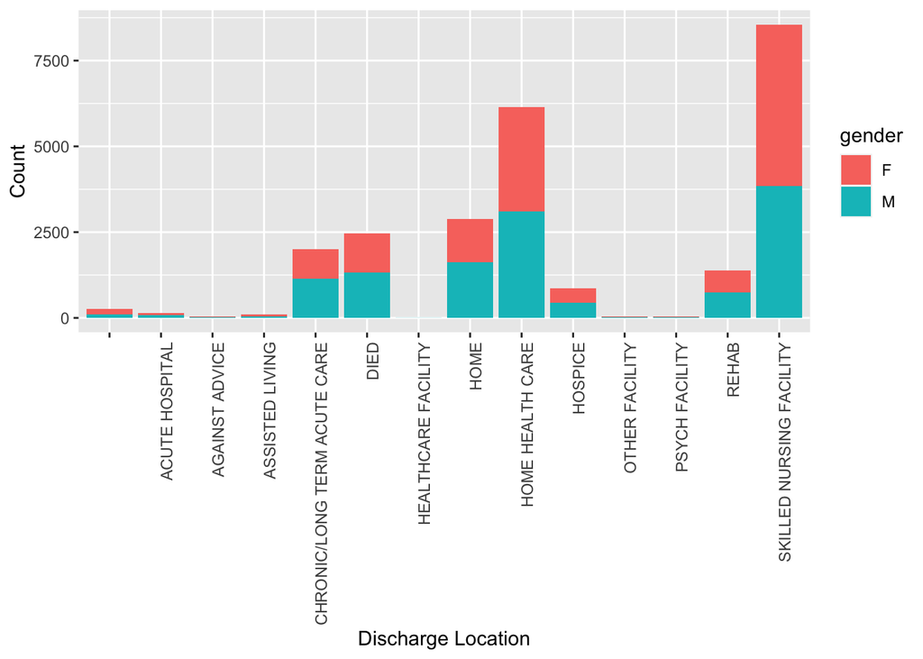

```r
# 12% went home; 25% went home with HHC (among all inhosp older sepsis patients)

inhosp_older_sepsis |>
  ggplot(aes(x = discharge_location, fill = gender)) +
  geom_bar() +
  labs(x = "Discharge Location", y = "Count") +
  theme(axis.text.x = element_text(angle = 90, hjust = 1))
```

```r
# Select patients who went home without any services or with HHC
inhosp_older_sepsis_home <- inhosp_older_sepsis |>
  filter(discharge_location == "HOME" | discharge_location == "HOME HEALTH CARE")

# Change structure of the variable: character to factor
inhosp_older_sepsis_home$discharge_location <- as.factor(inhosp_older_sepsis_home$discharge_location)
table(inhosp_older_sepsis_home$discharge_location) # 1= HOME; 2 = HOME HEALTH CARE
```

```
            HOME HOME HEALTH CARE
            2893             6141
```

```r
inhosp_older_sepsis_home |>
  select(discharge_location)|>
  tbl_summary()
```

| **Characteristic** | **N = 9,034**<sup>1</sup> |
| --- | --- |
| discharge_location |  |
| HOME | 2,893 (32%) |
| HOME HEALTH CARE | 6,141 (68%) |

<sup>1</sup> n (%)

```r
inhosp_older_sepsis_home |>
  select(age)|>
  describe()
```

```
    vars    n  mean   sd median trimmed mad min max range skew kurtosis   se
age    1 9034 76.56 8.11     75   76.05 8.9  65 100    35 0.44    -0.78 0.09
```

```r
# 32% went home; 68% went home with HHC (among older sepsis patients with inhospital stays went either home or HHC)

# data frame
# inhosp_older_sepsis2 = joined inhosp_older_sepsis with admissions table
# inhosp_older_sepsis_home = filtered to 'sepsis == 1' & 'age >= 65' & 'discharge_location = "HOME" | discharge_location = "HOME HEALTH CARE"' (9034 admissions)
```

Now, as we have identified our cohort, now I am going to make predictors in a format that I would like to include in a model.

## 5.1 Manipulating Predictors

### 5.1.1 Demographic characteristics

I will collapse categories of several demographic characteristics for analysis.

- race

```r
table(inhosp_older_sepsis_home$race) # total of 33 races
```

```
            AMERICAN INDIAN/ALASKA NATIVE
                                       14
                                    ASIAN
                                      107
                     ASIAN - ASIAN INDIAN
                                       36
                          ASIAN - CHINESE
                                      163
                           ASIAN - KOREAN
                                        7
                 ASIAN - SOUTH EAST ASIAN
                                       32
                            BLACK/AFRICAN
                                       37
                   BLACK/AFRICAN AMERICAN
                                      998
                       BLACK/CAPE VERDEAN
                                      136
                   BLACK/CARIBBEAN ISLAND
                                       62
                       HISPANIC OR LATINO
                                       76
       HISPANIC/LATINO - CENTRAL AMERICAN
                                       11
              HISPANIC/LATINO - COLUMBIAN
                                        5
                  HISPANIC/LATINO - CUBAN
                                       11
              HISPANIC/LATINO - DOMINICAN
                                       62
             HISPANIC/LATINO - GUATEMALAN
                                       29
               HISPANIC/LATINO - HONDURAN
                                       13
                HISPANIC/LATINO - MEXICAN
                                        7
           HISPANIC/LATINO - PUERTO RICAN
                                      120
             HISPANIC/LATINO - SALVADORAN
                                        9
```

[output cut: 11 more lines]

```
                                       16
                         UNABLE TO OBTAIN
                                       23
                                  UNKNOWN
                                      175
                                    WHITE
                                     6074
                        WHITE - BRAZILIAN
                                        9
                 WHITE - EASTERN EUROPEAN
                                       33
                   WHITE - OTHER EUROPEAN
                                      208
                          WHITE - RUSSIAN
                                      212
```

```r
sum(is.na(inhosp_older_sepsis_home$race)) # no missing values
```

```
[1] 0
```

```r
## MAY NEED TO SPLIT UNKNOWN & OTHER ??#####
otherunknown_race <- c("AMERICAN INDIAN/ALASKA NATIVE", "MULTIPLE RACE/ETHNICITY", "NATIVE HAWAIIAN OR OTHER PACIFIC ISLANDER", "OTHER", "PATIENT DECLINED TO ANSWER", "PORTUGUESE", "SOUTH AMERICAN", "UNABLE TO OBTAIN", "UNKNOWN")

inhosp_older_sepsis_home <- inhosp_older_sepsis_home |>
  mutate(race_cate = case_when(
    str_detect(race, "^WHITE") ~ "WHITE",
    str_detect(race, "^BLACK") ~ "BLACK",
    str_detect(race, "^HISPANIC") ~ "HISPANIC",
    str_detect(race, "^ASIAN") ~ "ASIAN",
    race %in% otherunknown_race ~ "OTHER/UNKNOWN"
  ))

# Change to factor
inhosp_older_sepsis_home$race_cate <- factor(inhosp_older_sepsis_home$race_cate,
                                   levels = c("WHITE", "BLACK", "HISPANIC",
                                              "ASIAN", "OTHER/UNKNOWN")
                                   )
table(inhosp_older_sepsis_home$race_cate)
```

```
        WHITE         BLACK      HISPANIC         ASIAN OTHER/UNKNOWN
         6536          1233           343           345           577
```

```r
# Validate code
table(inhosp_older_sepsis_home$race_cate)
```

```
        WHITE         BLACK      HISPANIC         ASIAN OTHER/UNKNOWN
         6536          1233           343           345           577
```

```r
sum(is.na(inhosp_older_sepsis_home$race_cate))
```

```
[1] 0
```

```r
# Compare with entire breakdown of race
admissions |>
  select(race) |>
  tbl_summary()
```

| **Characteristic** | **N = 431,231**<sup>1</sup> |
| --- | --- |
| race |  |
| AMERICAN INDIAN/ALASKA NATIVE | 919 (0.2%) |
| ASIAN | 6,156 (1.4%) |
| ASIAN - ASIAN INDIAN | 1,198 (0.3%) |
| ASIAN - CHINESE | 5,587 (1.3%) |
| ASIAN - KOREAN | 506 (0.1%) |
| ASIAN - SOUTH EAST ASIAN | 1,446 (0.3%) |
| BLACK/AFRICAN | 2,530 (0.6%) |
| BLACK/AFRICAN AMERICAN | 59,959 (14%) |
| BLACK/CAPE VERDEAN | 4,765 (1.1%) |
| BLACK/CARIBBEAN ISLAND | 2,704 (0.6%) |
| HISPANIC OR LATINO | 7,754 (1.8%) |
| HISPANIC/LATINO - CENTRAL AMERICAN | 437 (0.1%) |
| HISPANIC/LATINO - COLUMBIAN | 639 (0.1%) |
| HISPANIC/LATINO - CUBAN | 500 (0.1%) |
| HISPANIC/LATINO - DOMINICAN | 4,383 (1.0%) |
| HISPANIC/LATINO - GUATEMALAN | 1,330 (0.3%) |
| HISPANIC/LATINO - HONDURAN | 536 (0.1%) |
| HISPANIC/LATINO - MEXICAN | 665 (0.2%) |
| HISPANIC/LATINO - PUERTO RICAN | 8,076 (1.9%) |
| HISPANIC/LATINO - SALVADORAN | 892 (0.2%) |
| MULTIPLE RACE/ETHNICITY | 560 (0.1%) |
| NATIVE HAWAIIAN OR OTHER PACIFIC ISLANDER | 386 (<0.1%) |
| OTHER | 15,102 (3.5%) |
| PATIENT DECLINED TO ANSWER | 1,761 (0.4%) |
| PORTUGUESE | 1,510 (0.4%) |
| SOUTH AMERICAN | 505 (0.1%) |
| UNABLE TO OBTAIN | 1,603 (0.4%) |
| UNKNOWN | 10,668 (2.5%) |
| WHITE | 272,932 (63%) |
| WHITE - BRAZILIAN | 1,103 (0.3%) |
| WHITE - EASTERN EUROPEAN | 1,170 (0.3%) |
| WHITE - OTHER EUROPEAN | 7,925 (1.8%) |
| WHITE - RUSSIAN | 5,024 (1.2%) |

<sup>1</sup> n (%)

- marital status

```r
table(inhosp_older_sepsis_home$marital_status) # Divorced, Married, Single, Widowed, missing value (126)
```

```
         DIVORCED  MARRIED   SINGLE  WIDOWED
     126      639     4744     1572     1953
```

```r
sum(is.na(inhosp_older_sepsis_home$marital_status)) # no NAs
```

```
[1] 0
```

```r
inhosp_older_sepsis_home <- inhosp_older_sepsis_home |>
  filter(marital_status != "")

# Change to factor
inhosp_older_sepsis_home <- inhosp_older_sepsis_home |>
  mutate(marital_status_cate = factor(marital_status,
                            levels = c("MARRIED", "SINGLE",
                                       "DIVORCED", "WIDOWED")))

# Validate code
table (inhosp_older_sepsis_home$marital_status_cate)
```

```
 MARRIED   SINGLE DIVORCED  WIDOWED
    4744     1572      639     1953
```

- insurance

```r
table(inhosp_older_sepsis_home$insurance) # Medicare, Medicaid, Other
```

```
Medicaid Medicare    Other
     236     5786     2886
```

```r
sum(is.na(inhosp_older_sepsis_home$insurance)) # no missing values
```

```
[1] 0
```

```r
# Change to factor
inhosp_older_sepsis_home <- inhosp_older_sepsis_home |>
  mutate(insurance = factor(insurance,
                            levels = c("Medicare", "Medicaid", "Other")))

# Validate code
table (inhosp_older_sepsis_home$insurance)
```

```
Medicare Medicaid    Other
    5786      236     2886
```

- gender

```r
table(inhosp_older_sepsis_home$gender) # pretty even distribution
```

```
   F    M
4243 4665
```

```r
sum(is.na(inhosp_older_sepsis_home$gender)) # no missing values
```

```
[1] 0
```

```r
# Change to factor
inhosp_older_sepsis_home <- inhosp_older_sepsis_home |>
  mutate(gender = factor(gender,
                            levels = c("M", "F")))

# Validate code
table (inhosp_older_sepsis_home$gender)
```

```
   M    F
4665 4243
```

### 5.1.2 Clinical characteristics

- admission type

```r
table(inhosp_older_sepsis_home$admission_type)
```

```
               DIRECT EMER.          DIRECT OBSERVATION
                        503                           2
                   ELECTIVE              EU OBSERVATION
                        104                           8
                   EW EMER.           OBSERVATION ADMIT
                       4973                        2432
SURGICAL SAME DAY ADMISSION                      URGENT
                        148                         738
```

```r
sum(is.na(inhosp_older_sepsis_home$admission_type)) # no missing values
```

```
[1] 0
```

```r
adm_nonemergent <- c("ELECTIVE", "SURGICAL SAME DAY ADMISSION")
adm_emergent <- c("DIRECT EMER.", "DIRECT OBSERVATION", "EU OBSERVATION", "EW EMER.", "OBSERVATION ADMIT", "URGENT")

inhosp_older_sepsis_home <- inhosp_older_sepsis_home |>
  mutate(admission_type_cate = case_when(
    admission_type %in% adm_nonemergent ~ "Elective",
    admission_type %in% adm_emergent ~ "Emergent"
  ))

table (inhosp_older_sepsis_home$admission_type_cate)
```

```
Elective Emergent
     252     8656
```

```r
sum(is.na(inhosp_older_sepsis_home$admission_type_cate))
```

```
[1] 0
```

```r
# Change to factor
inhosp_older_sepsis_home <- inhosp_older_sepsis_home |>
  mutate(admission_type_cate = factor(admission_type_cate,
                            levels = c("Elective", "Emergent")))

# Validate code
table (inhosp_older_sepsis_home$admission_type_cate)
```

```
Elective Emergent
     252     8656
```

- Hospital length of stay

```r
inhosp_older_sepsis_home |>
  select(hosp_los) |>
  describe()
```

```
         vars    n mean   sd median trimmed  mad min    max  range skew
hosp_los    1 8908 7.96 8.54   5.72    6.39 3.35   2 295.99 293.99 8.09
         kurtosis   se
hosp_los   171.24 0.09
```

- number of previous hospitalization

Now we are going to make a predictor variable that tells us number of previous hospitalizations in the past 90days.

```r
admissions <- admissions |>
  group_by(subject_id) |>
  arrange(subject_id, admittime) |> # make sure the data frame is arrange by admittime before running the below for-loop code
  mutate(prev90d = admittime - days(90)) |>
  ungroup()

sum(is.na(admissions$prev90d)) # confirmed that there is no missing value
```

```
[1] 10925
```

```r
admissions <- admissions |>
  group_by(subject_id) |>
  arrange(subject_id, admittime) |>
  mutate(prev90d_hosp = ifelse(is.na(dplyr::lag(dischtime)) |
                                  dplyr::lag(dischtime) < prev90d, 0, 1)) |>
  mutate(prev90d_hosp = factor(prev90d_hosp, levels = c(0, 1), labels = c(0, 1))) |>
  ungroup()

prev90d_hosp_sum <- integer()
for (i in 1:nrow(admissions)) {
  if(i == 1) # first row coded 0 bc no previous hospitalization is present
    prev90d_hosp_sum[i] <- 0
  else if(i < 21) { # set for 20 because that was the maximum value one was hospitalized within 90 day time frame
    this_patient <- admissions$subject_id[i]
    this_prev90d <- admissions$prev90d[i]
    this_admittime <- admissions$admittime[i]

    prev90d_hosp_sum[i] <- admissions |>
      filter(subject_id == this_patient &
               dischtime >= this_prev90d &
               admittime < this_admittime) |>
      nrow()
  } else{
    this_patient <- admissions$subject_id[i]
    this_prev90d <- admissions$prev90d[i]
    this_admittime <- admissions$admittime[i]

    prev90d_hosp_sum[i] <- admissions[(i-20):i,] |>
      filter(subject_id == this_patient &
               dischtime >= this_prev90d &
               admittime < this_admittime) |>
      nrow()
  }
}

admissions$prev90d_hosp_sum <- prev90d_hosp_sum

admissions2 <- admissions |>
  select(subject_id, hadm_id, prev90d, prev90d_hosp, prev90d_hosp_sum)

inhosp_older_sepsis_home <- inhosp_older_sepsis_home |>
  left_join(admissions2, by = c("subject_id", "hadm_id"))
```

- ICU history

```r
# Make a binary ICU history outcome
icustays <- read_csv(file="/Users/sangbin/Library/Mobile Documents/com~apple~CloudDocs/Penn/ONR/MIMIC/mimic-iv-2.2/icu/icustays.csv.gz")
icustays |>
  summarise(n_distinct(stay_id),
            n_distinct(subject_id))
```

```
# A tibble: 1 × 2
  `n_distinct(stay_id)` `n_distinct(subject_id)`
                  <int>                    <int>
1                 73181                    50920
```

```r
# Number of ICU admissions 73181 and number of distinct patients 50920
# Confirmed that the number of ICU admissions match with MIMIC-IV data

# icustays file consist of patients who had icu stays
# Check if hadm_id in admissions table is found in icustays dataframe
inhosp_older_sepsis_home <- inhosp_older_sepsis_home |>
  mutate(
    icu_hx = case_when(
    hadm_id %in% (icustays$hadm_id) ~ 1,
      TRUE ~ 0
    )
  )

# Change to a factor
inhosp_older_sepsis_home <- inhosp_older_sepsis_home |>
  mutate(icu_hx = factor(icu_hx, levels = c(0, 1)))

table(inhosp_older_sepsis_home$icu_hx)
```

```
   0    1
6262 2646
```

```r
# variable
# icu_hx = hadm_id with stay_id coded 1; without stay_id coded 0
```

- Elixhauser Comorbidity Score

  Before making the comorbidity scores, since MIMIC-IV contains both ICD version 9 and 10, I will investigate cases with two versions of ICD codes for an admission episode and whether there are any duplicates.

```r
# Check if hospital admission ID can have ICD codes from both versions
test_icd <- icd |>
  group_by(hadm_id) |>
  summarise(unique_icd = n_distinct(icd_version))
table(test_icd$unique_icd)
```

```
     1      2
430842     10
```

```r
test_icd |>
  filter(unique_icd == 2)
```

```
# A tibble: 10 × 2
    hadm_id unique_icd
      <dbl>      <int>
 1 20216016          2
 2 21575927          2
 3 22870827          2
 4 23076003          2
 5 23969809          2
 6 24773199          2
 7 27016754          2
 8 27635276          2
 9 28333632          2
10 29918558          2
```

```r
# There are 10 cases where two versions of ICD codes have been used
# Need to spearate for ICD 9 and ICD 10 codes
```

```r
# Investigate if there are any duplicates between ICD 9 and 10
icd_test <- icd |>
  filter(hadm_id %in% c("20216016", "21575927", "22870827", "23076003", "23969809", "24773199", "27016754", "27635276", "28333632", "29918558"))

# read in the icd_dictionary
d_icd <- read.csv(file="/Users/sangbin/Library/Mobile Documents/com~apple~CloudDocs/Penn/ONR/MIMIC/mimic-iv-2.2/hosp/d_icd_diagnoses 3.csv")

icd_test_dict <- icd_test |>
  left_join(d_icd, by = c("icd_version", "icd_code"))

icd_test_dict |> head(20)
# there are some overlap between versions, but not necessarily exactly same
# and their length of hosp los was not that long either
# thus, decided to exclude 10 cases
# although, some of cases had sepsis a diagnosis, they were not included in inhosp_older_sepsis_home cohort
```

```r
# Exclude 10 cases that have two ICD versions for one hadm_id
icd_uniquev <- icd |>
  filter(!hadm_id %in% c("20216016", "21575927", "22870827", "23076003", "23969809", "24773199", "27016754", "27635276", "28333632", "29918558"))

# Manipulate the ICD dataset to put all ICD codes for each hospital admission episode into a single row
test_icd1 <- icd_uniquev |>
  group_by(hadm_id) |>
  filter(all(icd_version == 9)) |> # only selected hadm_ids with icd9 codes
   summarise(
    icd9_code = paste(case_when(
      icd_version == 9 ~ as.character(icd_code)),
      collapse = ", "))

test_icd2 <- icd_uniquev |>
  group_by(hadm_id) |>
  filter(all(icd_version == 10)) |> # only selected hadm_ids with icd10 codes
   summarise(
    icd10_code = paste(case_when(
      icd_version == 10 ~ as.character(icd_code)),
      collapse = ", "))

# Create a dataframe with the Elixhauser comorbidity scores
icd9_comorbidity <- comorbidity::comorbidity(x= test_icd1, id = "hadm_id", code = "icd9_code", map = "elixhauser_icd9_quan", assign0 = FALSE)
icd9_comorbidity$elixhauser9 <- score(x = icd9_comorbidity, weights = "vw",
                                       assign0 = FALSE)

icd10_comorbidity <- comorbidity::comorbidity(x= test_icd2, id = "hadm_id", code = "icd10_code", map = "elixhauser_icd10_quan", assign0 = FALSE)
icd10_comorbidity$elixhauser10 <- score(x = icd10_comorbidity, weights = "vw",
                                         assign0 = FALSE)

table(icd9_comorbidity$elixhauser9)
```

```
    -7     -4     -3     -2     -1      0      2      3      4      5      6
  1117    903   6525    439   2527 219455   4955   3692   9311  10618   3883
     7      9     11     12     13
  6576   1085   2678   3027      2
```

```r
table(icd10_comorbidity$elixhauser10)
```

```
    -7     -4     -3     -2     -1      0      2      3      4      5      6
   495    400   4189    284   2031 119876   1564   1975   5967   5521   2150
     7      9     11     12
  5210    726   1979   1682
```

```r
# Changing the variable for elixhausesr score into a same name to combine two dataframes together
icd9_comorbidity <- icd9_comorbidity |>
  rename(comorbidity = elixhauser9) |>
  select(hadm_id, comorbidity)

icd10_comorbidity <- icd10_comorbidity |>
  rename(comorbidity = elixhauser10) |>
  select( hadm_id, comorbidity)

# Combine two dataframes
comorbidities <- bind_rows(icd9_comorbidity, icd10_comorbidity) #430842 observations
# icd9_comorbidity: 276793
# icd10_comorbidity: 154049
# comorbidities: combined the two (276793 + 154049 = 430842)
# successfully combined

# Join with our cohort
inhosp_older_sepsis_home <- inhosp_older_sepsis_home |>
  left_join(comorbidities, by = "hadm_id") |>
  arrange(subject_id, admittime)
# 8908 admissions

table(inhosp_older_sepsis_home$comorbidity)
```

```
  -7   -3   -2   -1    0    2    3    4    5    6    7    9   11   12
   4    5   12   88 6951   72  258  234  247   54  649   76  184   74
```

```r
# variable
# comorbidity = elixhauser comorbidity scores based on their icd code versions
```

## 5.2 Outcome

```r
# 30day rehospitalization & 60day rehospitalization

admissions <- admissions |>
  arrange(subject_id, admittime) |>
  group_by(subject_id) |>
  mutate(nextadm30d = dischtime + days(30)) |>
  mutate(rehosp30d = ifelse(is.na(dplyr::lead(admittime)) |
                              dplyr::lead(admittime) > nextadm30d, 0, 1)) |>
  mutate(nextadm60d = dischtime + days(60)) |>
  mutate(rehosp60d = ifelse(is.na(dplyr::lead(admittime)) |
                              dplyr::lead(admittime) > nextadm60d, 0, 1)) |>
  mutate(rehosp30d = factor(rehosp30d, levels = c(0, 1))) |>
  mutate(rehosp60d = factor(rehosp60d, levels = c(0, 1))) |>
  ungroup()

admissions |> # validate code
  select(subject_id, hadm_id, admittime, nextadm30d, rehosp30d, nextadm60d, rehosp60d)
```

```
# A tibble: 431,231 × 7
   subject_id  hadm_id admittime           nextadm30d          rehosp30d
        <int>    <int> <dttm>              <dttm>              <fct>
 1   10000032 22595853 2180-05-06 22:23:00 2180-06-06 17:15:00 0
 2   10000032 22841357 2180-06-26 18:27:00 2180-07-27 18:49:00 1
 3   10000032 29079034 2180-07-23 12:35:00 2180-08-24 17:55:00 1
 4   10000032 25742920 2180-08-05 23:44:00 2180-09-06 17:50:00 0
 5   10000068 25022803 2160-03-03 23:16:00 2160-04-03 06:26:00 0
 6   10000084 23052089 2160-11-21 01:56:00 2160-12-25 14:52:00 0
 7   10000084 29888819 2160-12-28 05:11:00 2161-01-27 16:07:00 0
 8   10000108 27250926 2163-09-27 23:17:00 2163-10-28 09:04:00 0
 9   10000117 22927623 2181-11-15 02:05:00 2181-12-15 14:52:00 0
10   10000117 27988844 2183-09-18 18:10:00 2183-10-21 16:30:00 0
# ℹ 431,221 more rows
# ℹ 2 more variables: nextadm60d <dttm>, rehosp60d <fct>
```

```r
rehosp_adm <- admissions |>
  select (subject_id, hadm_id, nextadm30d, rehosp30d, nextadm60d, rehosp60d)

inhosp_older_sepsis_home <- inhosp_older_sepsis_home |>
  left_join(rehosp_adm, by = c("subject_id", "hadm_id"))


table(inhosp_older_sepsis_home$rehosp30d) # 2465 admissions had 30day readmission (27.7%)
```

```
   0    1
6443 2465
```

```r
table(inhosp_older_sepsis_home$rehosp60d) # 3283 admissions had 60day readmission (36.9%)
```

```
   0    1
5625 3283
```

```r
test <- inhosp_older_sepsis_home|>
  arrange(subject_id, admittime) |>
  group_by(subject_id) |>
  filter(row_number() == 1)

table(test$rehosp30d) # 1598 admissions had rehosp30day from their first admission
```

```
   0    1
5041 1598
```

```r
table(test$rehosp60d) # 2137 admissions had rehosp60day from their first admission
```

```
   0    1
4502 2137
```

As I have identified the cohort and made all of the variables I need for analysis, I will save the file.

```r
write_csv(inhosp_older_sepsis_home, "/Users/sangbin/Library/Mobile Documents/com~apple~CloudDocs/Penn/ONR/inhosp_older_sepsis_home_FINAL.csv")
```

# 6 Results

## 6.1 Descriptive Analysis

First, we will identify how many were discharged to Home & HHC, respectively.

```r
inhosp_older_sepsis_home |>
  select(discharge_location) |>
  tbl_summary()
```

| **Characteristic** | **N = 8,908**<sup>1</sup> |
| --- | --- |
| discharge_location |  |
| HOME | 2,855 (32%) |
| HOME HEALTH CARE | 6,053 (68%) |

<sup>1</sup> n (%)

Now, we will identify baseline characteristics of included hospital admissions.

### 6.1.1 Baseline demographic characteristics

```r
# Demo characteristics of the first admission (Baseline)
inhosp_older_sepsis_home |>
  arrange(subject_id, admittime) |>
  group_by(subject_id) |>
  filter(row_number() == 1) |> # limit to baseline
  group_by(discharge_location) |>
  select(gender, age, race_cate, insurance, marital_status, discharge_location) |>
  furniture::table1("Self-Identified Gender" = gender,
                    "Age" = age,
                    "Marital Status" = marital_status,
                    "Self-Identified Race" = race_cate,
                    "Health Insurance" = insurance,
                    caption = "Demographic Characteristics",
                    FUN = NULL, # report mean(sd) for numeric data
                    NAkeep = TRUE,
                    na.rm = FALSE,
                    total = TRUE,
                    test = TRUE
                    )
```

```
Using dplyr::group_by() groups: discharge_location
```

```
The test is for the stratified data relationships.
```

```
Breusch-Pagan Test of Heteroskedasticity suggests `var.equal = FALSE` in t.test() for: Age
```

```
 Demographic Characteristics
```

```
───────────────────────────────────────────────────────────────────────────
                                        discharge_location
                        Total        HOME         HOME HEALTH CARE P-Value
                        n = 6639     n = 2232     n = 4407
 Self-Identified Gender                                            <.001
    M                   3520 (53%)   1261 (56.5%) 2259 (51.3%)
    F                   3119 (47%)   971 (43.5%)  2148 (48.7%)
    NA                  0 (0%)       0 (0%)       0 (0%)
 Age                                                               <.001
                        76.6 (8.1)   74.6 (7.2)   77.6 (8.3)
 Marital Status                                                    <.001
    DIVORCED            455 (6.9%)   161 (7.2%)   294 (6.7%)
    MARRIED             3586 (54%)   1291 (57.8%) 2295 (52.1%)
    SINGLE              1162 (17.5%) 403 (18.1%)  759 (17.2%)
    WIDOWED             1436 (21.6%) 377 (16.9%)  1059 (24%)
    NA                  0 (0%)       0 (0%)       0 (0%)
 Self-Identified Race                                              0.081
    WHITE               4865 (73.3%) 1623 (72.7%) 3242 (73.6%)
    BLACK               875 (13.2%)  287 (12.9%)  588 (13.3%)
    HISPANIC            232 (3.5%)   72 (3.2%)    160 (3.6%)
    ASIAN               254 (3.8%)   105 (4.7%)   149 (3.4%)
    OTHER/UNKNOWN       413 (6.2%)   145 (6.5%)   268 (6.1%)
    NA                  0 (0%)       0 (0%)       0 (0%)
 Health Insurance                                                  <.001
    Medicare            4283 (64.5%) 1409 (63.1%) 2874 (65.2%)
    Medicaid            183 (2.8%)   89 (4%)      94 (2.1%)
    Other               2173 (32.7%) 734 (32.9%)  1439 (32.7%)
    NA                  0 (0%)       0 (0%)       0 (0%)
───────────────────────────────────────────────────────────────────────────
```

Baseline demographic characteristics (gender, age, marital status, and insurance) showed statistically significant difference between home vs HHC, except for race. Patients discharged home with HHC were less male, older, less married (but more widowed), and more Medicare-insured compared to patients discharged home without any services.

### 6.1.2 Baseline clinical characteristics

```r
# Clinical characteristics of the first admission (Baseline)
inhosp_older_sepsis_home |>
  arrange(subject_id, admittime) |>
  group_by(subject_id) |>
  filter(row_number() == 1) |> # limit to baseline
  group_by(discharge_location) |>
  select(admission_type_cate, discharge_location, comorbidity, hosp_los, prev90d_hosp_sum,
         icu_hx, rehosp30d) |>
  furniture::table1("Admission Type" = admission_type_cate,
                    "Elixhauser Comorbidity Scores" = comorbidity,
                    "Hospital LOS (days)" = hosp_los,
                    "Number of Previous Hospitalizations Within 90 Days" = prev90d_hosp_sum,
                    "ICU history" = icu_hx,
                    "Hospital Readmission Within 30 Days" = rehosp30d,
                    caption = "Clinical Characteristics",
                    FUN = NULL, # report mean(sd) for numeric data
                    NAkeep = TRUE,
                    total = TRUE,
                    test = TRUE
                    )
```

```
Using dplyr::group_by() groups: discharge_location
```

```
The test is for the stratified data relationships.
```

```
Breusch-Pagan Test of Heteroskedasticity suggests `var.equal = FALSE` in t.test() for: Elixhauser.Comorbidity.Scores
```

```
Breusch-Pagan Test of Heteroskedasticity suggests `var.equal = FALSE` in t.test() for: Number.of.Previous.Hospitalizations.Within.90.Days
```

```
 Clinical Characteristics
```

```
───────────────────────────────────────────────────────────────────────────────────────────────────────
                                                                    discharge_location
                                                    Total        HOME
                                                    n = 6639     n = 2232
 Admission Type
    Elective                                        214 (3.2%)   61 (2.7%)
    Emergent                                        6425 (96.8%) 2171 (97.3%)
 Elixhauser Comorbidity Scores
                                                    1.2 (2.7)    1.0 (2.6)
 Hospital LOS (days)
                                                    8.0 (9.0)    6.6 (8.0)
 Number of Previous Hospitalizations Within 90 Days
                                                    0.4 (0.8)    0.3 (0.7)
 ICU history
    0                                               4545 (68.5%) 1666 (74.6%)
    1                                               2094 (31.5%) 566 (25.4%)
 Hospital Readmission Within 30 Days
    0                                               5041 (75.9%) 1748 (78.3%)
    1                                               1598 (24.1%) 484 (21.7%)
 HOME HEALTH CARE P-Value
 n = 4407
                  0.124
 153 (3.5%)
 4254 (96.5%)
                  <.001
 1.3 (2.8)
                  <.001
 8.8 (9.4)
                  <.001
 0.5 (0.8)
                  <.001
 2879 (65.3%)
 1528 (34.7%)
                  0.001
 3293 (74.7%)
 1114 (25.3%)
───────────────────────────────────────────────────────────────────────────────────────────────────────
```

Here, I am going to examine the number of hospitalization for each subject_id and its distribution.

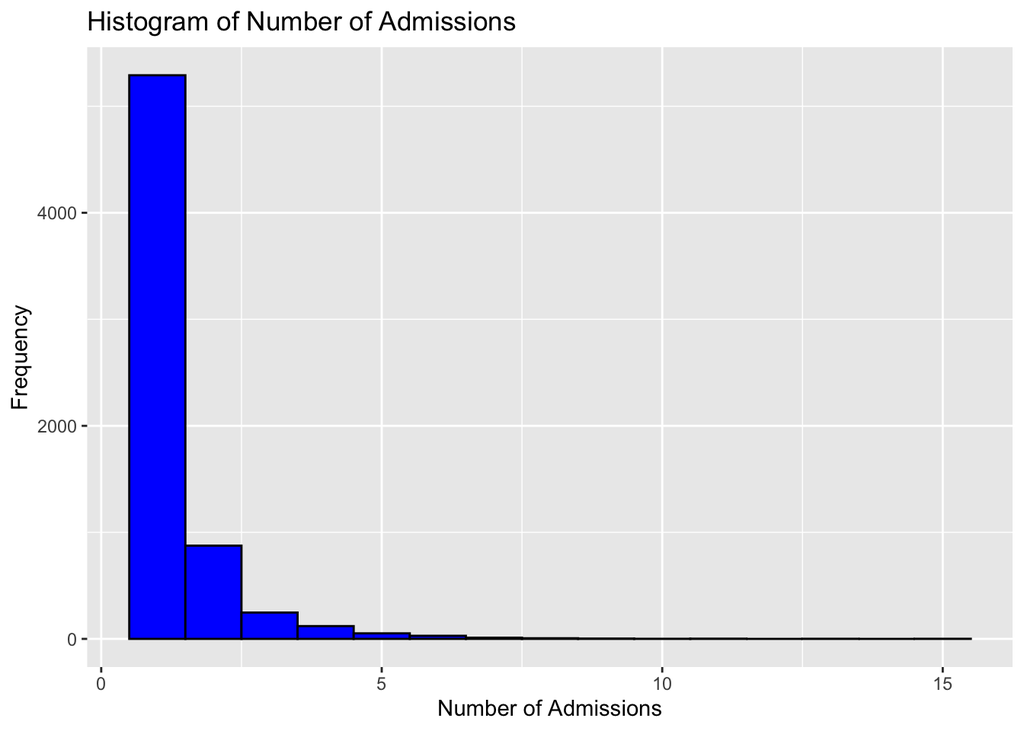

```r
# How many hospitalizations did the our cohort had within 2008 - 2019 time frame
df <- inhosp_older_sepsis_home |>
  group_by(subject_id) |>
  summarize(n_admission = n()) |>
  arrange(desc(n_admission))

ggplot(df, aes(x = n_admission)) +
  geom_histogram(binwidth = 1, fill = "blue", color = "black") +
  labs(title = "Histogram of Number of Admissions", x = "Number of Admissions", y = "Frequency")
```

```r
df |>
  janitor::tabyl(n_admission) |>
  arrange(desc(n_admission))
```

```
 n_admission    n      percent
          15    1 0.0001506251
          13    1 0.0001506251
          11    2 0.0003012502
          10    1 0.0001506251
           9    3 0.0004518753
           8    6 0.0009037506
           7   11 0.0016568760
           6   29 0.0043681277
           5   52 0.0078325049
           4  120 0.0180750113
           3  247 0.0372043983
           2  875 0.1317969574
           1 5291 0.7969573731
```

## 6.2 GEE Logistic Regression

As an explanatory purposes, I will include all of the predictors into the model. I will use exchangeable correlation structure, which assumes that the observations within subject are equally correlated.

```r
gee_model1 <- gee(rehosp30d ~ gender + age + race_cate + insurance +
                    marital_status+ discharge_location + admission_type_cate +
                    hosp_los + prev90d_hosp_sum + icu_hx,
                data = inhosp_older_sepsis_home,
                id = subject_id, # the clustering variable
                family = binomial(link= "logit"),
                corstr = "exchangeable")
```

```
Beginning Cgee S-function, @(#) geeformula.q 4.13 98/01/27
```

```
running glm to get initial regression estimate
```

```
                       (Intercept)                            genderF
                      -0.598436605                       -0.051005640
                               age                     race_cateBLACK
                      -0.010497481                       -0.042798440
                 race_cateHISPANIC                     race_cateASIAN
                       0.114435183                        0.124222974
            race_cateOTHER/UNKNOWN                  insuranceMedicaid
                      -0.266193688                       -0.256166979
                    insuranceOther              marital_statusMARRIED
                      -0.061584617                       -0.041944770
              marital_statusSINGLE              marital_statusWIDOWED
                      -0.007090768                        0.056422726
discharge_locationHOME HEALTH CARE        admission_type_cateEmergent
                       0.137124941                       -0.004103537
                          hosp_los                   prev90d_hosp_sum
                       0.021490173                        0.421956433
                           icu_hx1
                      -0.187952283
```

```r
summary(gee_model1)
```

```
 GEE:  GENERALIZED LINEAR MODELS FOR DEPENDENT DATA
 gee S-function, version 4.13 modified 98/01/27 (1998)

Model:
 Link:                      Logit
 Variance to Mean Relation: Binomial
 Correlation Structure:     Exchangeable

Call:
gee(formula = rehosp30d ~ gender + age + race_cate + insurance +
    marital_status + discharge_location + admission_type_cate +
    hosp_los + prev90d_hosp_sum + icu_hx, id = subject_id, data = inhosp_older_sepsis_home,
    family = binomial(link = "logit"), corstr = "exchangeable")

Summary of Residuals:
       Min         1Q     Median         3Q        Max
-0.9971233 -0.2570986 -0.2082425  0.5047065  0.8774798


Coefficients:
                                       Estimate  Naive S.E.     Naive z
(Intercept)                        -0.572062158 0.316140760 -1.80951725
genderF                            -0.061765099 0.055067800 -1.12161917
age                                -0.010815716 0.003562773 -3.03575789
race_cateBLACK                     -0.047410850 0.077664806 -0.61045475
race_cateHISPANIC                   0.116445943 0.133691656  0.87100382
race_cateASIAN                      0.130374756 0.134997506  0.96575678
race_cateOTHER/UNKNOWN             -0.277890494 0.120408252 -2.30790240
insuranceMedicaid                  -0.277052444 0.171920616 -1.61151379
insuranceOther                     -0.061088304 0.056283139 -1.08537485
marital_statusMARRIED              -0.032629839 0.103738009 -0.31454082
marital_statusSINGLE                0.003395832 0.113283483  0.02997641
marital_statusWIDOWED               0.076063466 0.113897654  0.66782294
discharge_locationHOME HEALTH CARE  0.137951461 0.057080797  2.41677532
admission_type_cateEmergent        -0.012037711 0.149449407 -0.08054707
hosp_los                            0.020740841 0.003052266  6.79522833
prev90d_hosp_sum                    0.383403285 0.023706585 16.17286019
icu_hx1                            -0.172445783 0.057003760 -3.02516503
                                   Robust S.E.    Robust z
(Intercept)                        0.315559026 -1.81285310
```

[output cut: 54 more lines]

```
 [1,] 0.06919445 0.06919445 0.06919445
 [2,] 0.06919445 0.06919445 0.06919445
 [3,] 0.06919445 0.06919445 0.06919445
 [4,] 0.06919445 0.06919445 0.06919445
 [5,] 0.06919445 0.06919445 0.06919445
 [6,] 0.06919445 0.06919445 0.06919445
 [7,] 0.06919445 0.06919445 0.06919445
 [8,] 0.06919445 0.06919445 0.06919445
 [9,] 0.06919445 0.06919445 0.06919445
[10,] 0.06919445 0.06919445 0.06919445
[11,] 0.06919445 0.06919445 0.06919445
[12,] 0.06919445 0.06919445 0.06919445
[13,] 1.00000000 0.06919445 0.06919445
[14,] 0.06919445 1.00000000 0.06919445
[15,] 0.06919445 0.06919445 1.00000000
```

- Raw Estimates

```r
texreg::knitreg(list(gee_model1),
                custom.model.names = "GEE_Exchangeable Model",
                caption = "Estimates on Logit Scale",
                file = "GEE_coefficients_FINAL.doc",
                single.row = TRUE,
                digits = 4)
```

```
The table was written to the file 'GEE_coefficients_FINAL.doc'.
```

- Exponentiate the Estimates (Odds Ratio Scale)

```r
# Helper <extract> functions forr exponentiation of parameters from regression models

remotes::install_github("sarbearschwartz/texreghelpr")
library(texreghelpr)
```

```r
texreg::knitreg(list(extract_gee_exp(gee_model1)),
                custom.model.namess = "GEE_Exchangeable Model",
                caption = "Estimates on Odds-Ratio Scale",
                file = "GEE_OR_FINAL.doc",
                single.row = TRUE,
                ci.test = 1,
                digits = 3)
```

```
The table was written to the file 'GEE_OR_FINAL.doc'.
```

- Estimates on both logit and odds-ratio scale

This is the final results of the GEE logistic regression model.

```r
texreg::knitreg(list(gee_model1,
                     texreghelpr::extract_gee_exp(gee_model1,
                                                  include.any = FALSE)),
                custom.model.names = c("b (SE)",
                                       "OR [95% CI]"),
                file = "GEE_RESULTS_FINAL.doc",
                caption = "GEE Exchangable Model",
                ci.test = 1,
                single.row = TRUE,
                digits = 3)
```

```
The table was written to the file 'GEE_RESULTS_FINAL.doc'.
```

[figure not shown]